# Typologie des compétences numériques des Français

Suppression de tous les ind qui ont répondu ‘nsp’,‘rdr’ ou ‘comprend.pas’ dans Skill

Laurent Mell, Nicolas Deporte &co

14 novembre 2017

### Préparation de la base pour l’analyse

On a un problème avec les individus qui ont répondu ‘nsp’,‘rdr’ ou ‘comprend.pas’. C’est un comportement “inhabituel” par rapport à la norme des réponses, qui va générer la création d’axes (dans les 1ers axes) dédiés à ‘nsp’,‘rdr’ ou ‘comprend.pas’ et ensuite générer des classes autour de ces réponses et brouiller la classification.

Il faut donc traiter ces réponses préalablement à l’AFM + HCPC.

2 solutions :

- soit on supprime simplement tous les individus qui ont répondu au moins une fois ‘nsp’,‘rdr’ ou ‘comprend.pas’. On enlève alors 402 répondants.
- soit on supprime seulement les individus qui ont répondu trop souvent ‘nsp’,‘rdr’ ou ‘comprend.pas’, par exemple, tous ceux qui ont répondu 3 fois ou plus ‘nsp’,‘rdr’ ou ‘comprend.pas’. On enlève alors seulement 146 répondants.

Ici on réalise la solution 1.

length(which(apply(skill[,17:37],1,function(x) any(x==“comprend.pas”))==TRUE)) length(which(apply(skill[,17:37],1,function(x) any(x==“nsp”))==TRUE))

226 répondants ont répondu au moins 1 fois “Ne comprend pas” 200 répondants ont répondu au moins 1 fois “Ne sait pas”

La préparation est faite !

### AFM

```r
#load(file="skill.Rdata")
resMFA <- MFA(skill, group=c(15,1,4,5,4,4,4), type=c("n","c","n","n","n","n","n"), ncp=24, name.group=c("Illustratives","Pondération","Comp. opérationnelles","Comp. informationnelles","Comp. sociales","Comp. créatives","Comp. mobiles"), num.group.sup=c(1,2), graph=FALSE, row.w=skill$poids)
# ou ncp=24 -> 75% de l'inertie initiale est conservée (pour la CAH)
#summary(resMFA)

#save(resMFA, file="resMFA.Rdata")
```

### Histogramme des valeurs propres

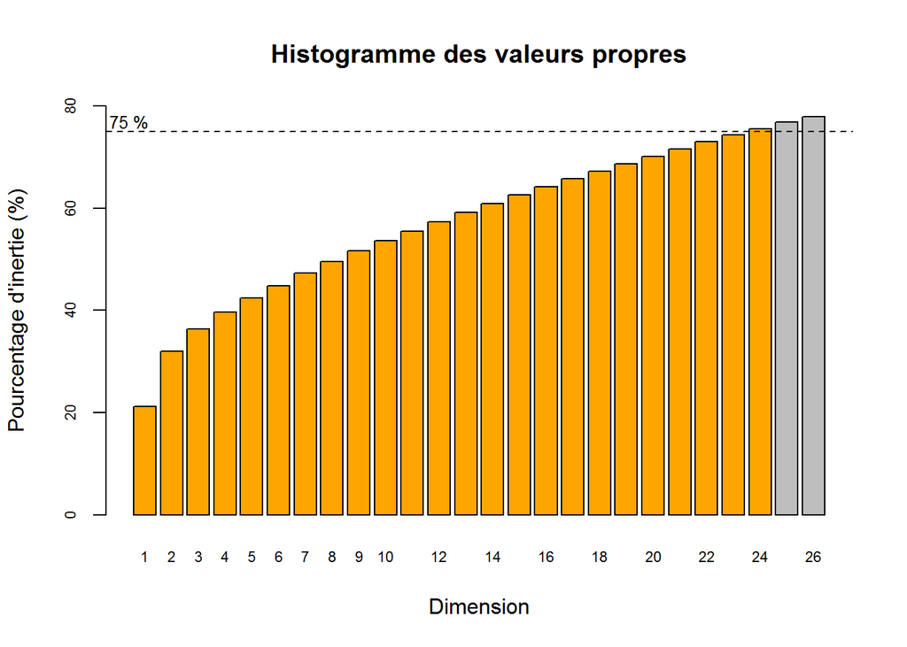

```r
load(file="resMFA.Rdata")
barplot(resMFA$eig[1:26,3], main="Histogramme des valeurs propres",
        xlab="Dimension", ylab="Pourcentage d'inertie (%)", cex.axis=0.7, cex.names=0.7,
        col=c(rep("orange",24),rep("gray",2)), names.arg=1:26, ylim=c(0,80))
abline(h=75, lty=2)
text(x=0,y=77,labels="75 %",cex=0.8)
```

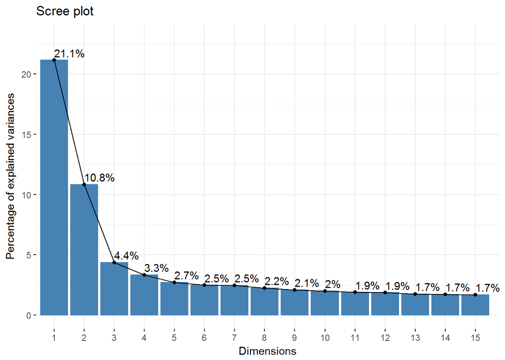

```r
fviz_eig(resMFA, choice="variance", ncp=15, addlabels=TRUE, ylim=c(0,23), xlim=c(1,15.2))
```

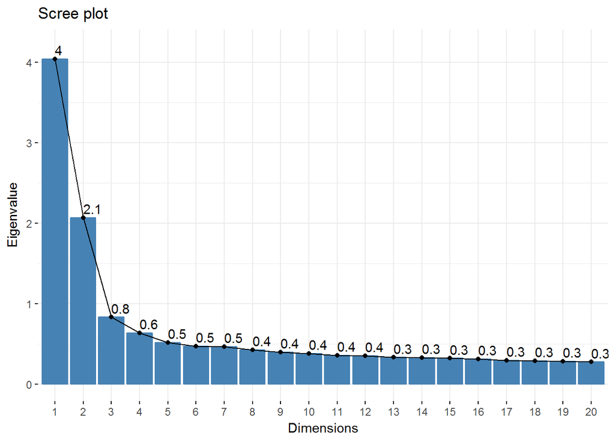

```r
fviz_eig(resMFA, choice="eigenvalue", ncp=20, addlabels=TRUE, ylim=c(0,4.2))
```

On garde les 24 premières composantes principales, ce qui permet de conserver 75% de l’inertie initiale du jeu de données.

Si on veut étudier les premiers axes de l’AFM, on peut regarder principalement les 4-5 premiers axes.

### Etude de l’AFM

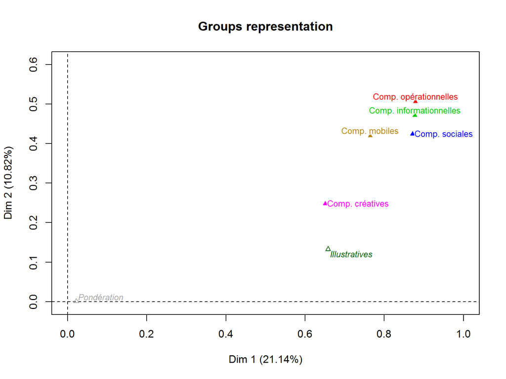

```r
# Groupes
#--------------------
# Représentation des groupes sur le 1er plan factoriel
plot(resMFA, choix=c("group"), shadowtext=TRUE, cex=0.8, ylim=c(0,0.6))
```

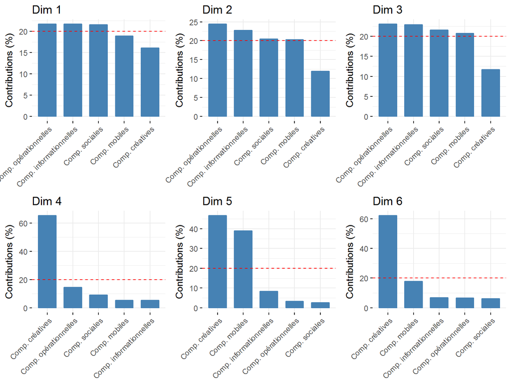

```r
#fviz_mfa_var(resMFA, "group")

# Contribution des groupes aux 6 premières dimensions
p1=fviz_contrib(resMFA, "group", axes=1) + ggtitle("Dim 1")
p2=fviz_contrib(resMFA, "group", axes=2) + ggtitle("Dim 2")
p3=fviz_contrib(resMFA, "group", axes=3) + ggtitle("Dim 3")
p4=fviz_contrib(resMFA, "group", axes=4) + ggtitle("Dim 4")
p5=fviz_contrib(resMFA, "group", axes=5) + ggtitle("Dim 5")
p6=fviz_contrib(resMFA, "group", axes=6) + ggtitle("Dim 6")
grid.arrange(p1,p2,p3,p4,p5,p6, ncol=3, nrow=2)
```

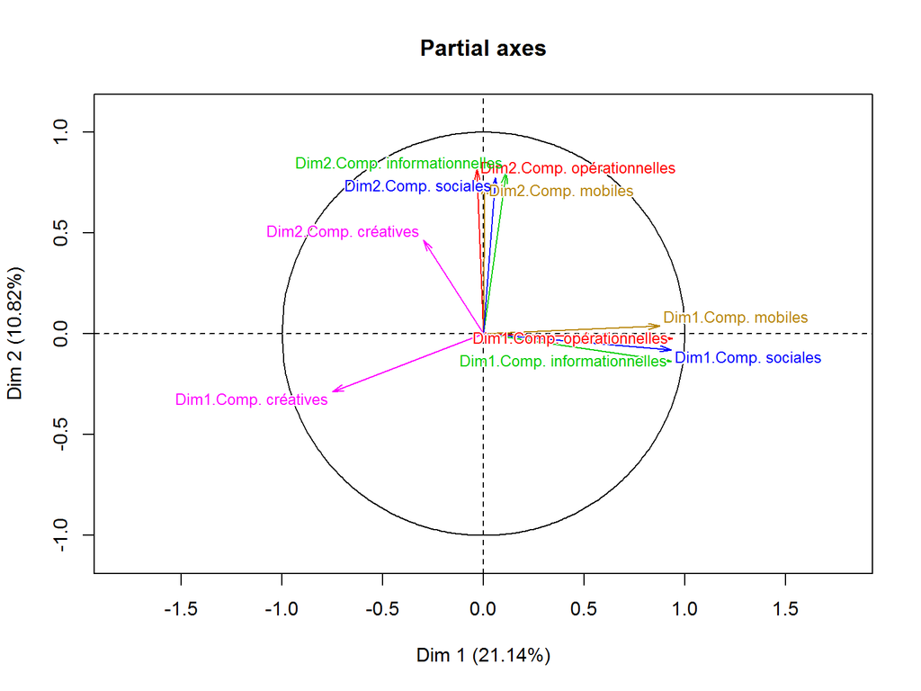

```r
# Axes partiels
#--------------------
# Représentation des axes partiels sur les axes de l'AFM
plot(resMFA, choix=c("axes"), cex=0.8, select="contrib 10", autoLab="auto", shadowtext=TRUE, legend=list(plot=FALSE))
```

```r
#fviz_mfa_axes(resMFA, select.axes=list(contrib=10), repel=TRUE) + theme(legend.position='none')



# # Qualité de représentation (cos2) des modalités des variables sur les axes factoriels
# var=get_mfa_var(resMFA, "quali.var")
# library(corrplot)
# corrplot(var$cos2, is.corr=FALSE)
# a=corrplot(var$contrib, is.corr=FALSE)
# corrplot(t(a))
```

La projection des groupes dans le premier plan factoriel montre une proximité importante entre les groupes “Compétences opérationnelles”, “informationnelles”, “sociales” et “mobiles”. Les compétences créatives quant à elles apparaissent relativement éloignées des 4 groupes précedemment cités. Cet éloignement traduit un rôle spécifique joué par les compétences créatives dans les profils de compétences des répondants. A l’inverse, la proximité constatée entre les 4 autres groupes traduit des profils assez proches d’un type de compétences à l’autre.

Ces 4 groupes de compétence ont des coordonnées positives élevées sur le plan factoriel 1-2 (1er quadrant) et contribuent fortement à la construction des axes 1, 2 et 3. Les compétences créatives ont une contribution moins forte sur ces axes. En revanche, elles vont très fortement contribuer aux axes 4, 5 et 6 et définir quasiment à elles seules les axes 4 et 6 (les compétences mobiles contribuent également fortement à l’axe 5).

La projection des axes partiels sur le premier plan de l’AFM montre que les dimensions 1 (resp. 2) des groupes “Compétences opérationnelles”, “mobiles”, “sociales” et “informationnelles” sont très corrélées positivement à la première (resp. deuxième) dimension de l’AFM. Tandis que la dimension 1 des compétences créatives est assez fortement corrélée négativement à la dimension 1 de l’AFM et que la dimension 2 de ces compétences est moyennement corrélée positivement à la dimension 2 de l’AFM. Ce qui confirme le rôle particulier joué par ce type de compétences dans la compétence numérique globale.

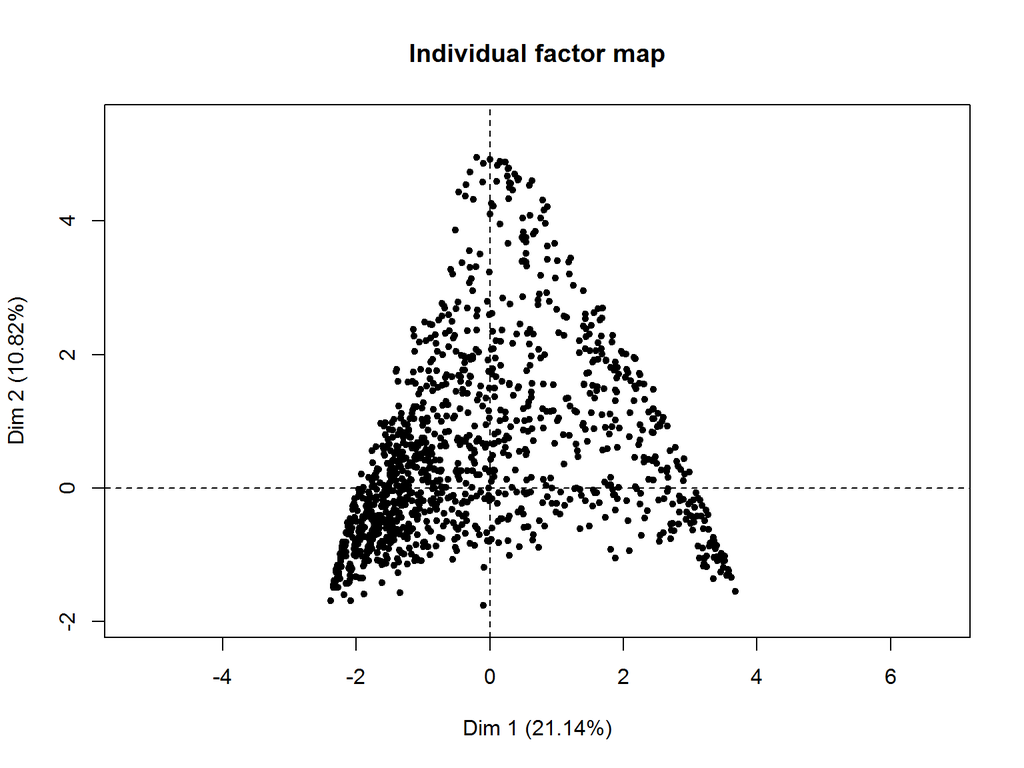

```r
# Individus
#--------------------
# Représentation des individus
plot(resMFA, choix=c("ind"), invisible=("quali"), lab.ind=FALSE)
```

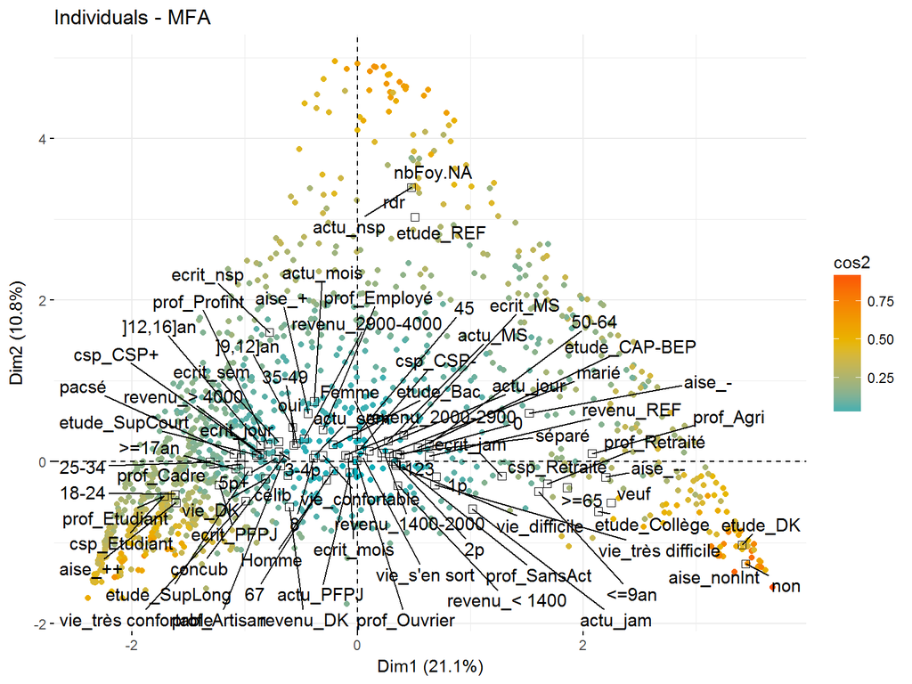

```r
# Représentation des individus colorés en fonction de leur cos2
fviz_mfa_ind(resMFA, col.ind="cos2", gradient.cols=c("#00AFBB","#E7B800","#FC4E07"), geom="point", label="none", invisible=c("var","quali.sup","quanti.sup"), repel=TRUE)
```

La projection des individus et des variables illustratives sur le premier plan factoriel laisse entrevoir une opposition le long de l’axe 1 entre les “jeunes, étudiants, très à l’aise avec Internet” situés sur la gauche du graphique et les “personnes âgées, retraités, pas à l’aise avec Internet voire non-internautes” situés sur la droite du graphique.

L’axe 1 présente également un gradient de compétences, des individus les plus compétents à gauche du graphique vers les individus les moins compétents à droite.

L’axe 2 oppose les individus extrêmes (très compétents ou très peu compétents) à gauche aux individus moyens (plutôt ou plutôt pas compétents) à droite.

L’axe 3 oppose les plutôt compétents (à gauche) aux plutôt pas compétents (à droite).

L’axe 4 oppose les très compétents créatifs (en haut et en particulier pour les compétences “savoir créer un site web” et “savoir programmer dans un langage informatique”) aux moins compétents (en bas).

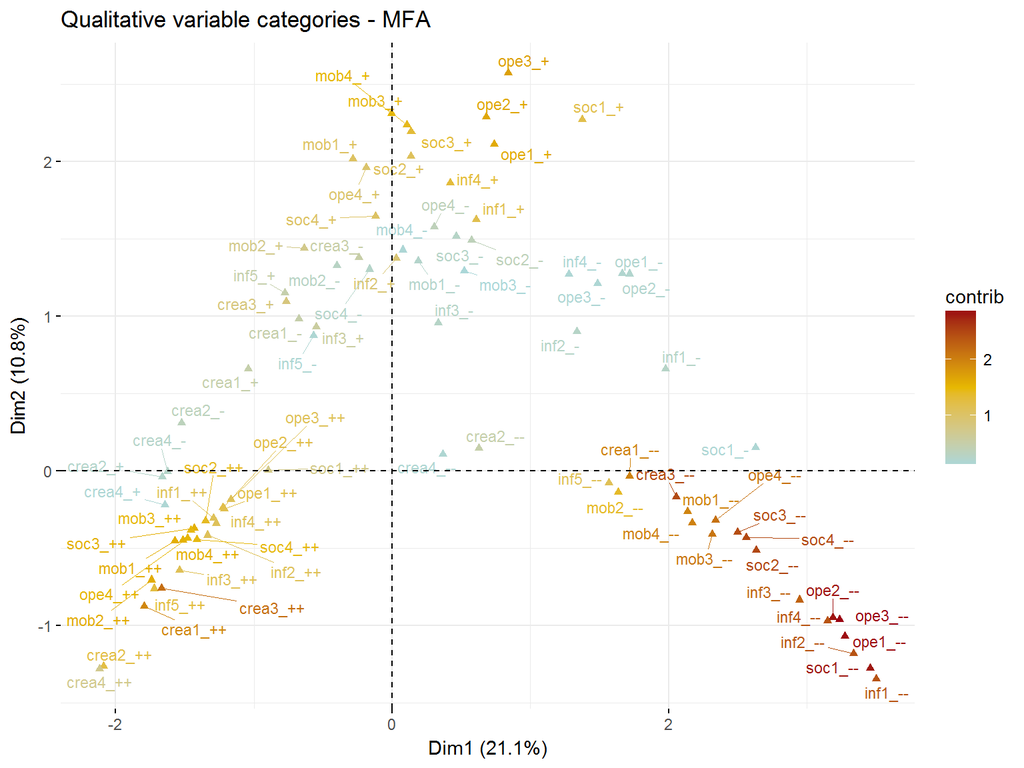

```r
# Modalités
#--------------------
# Représentation des modalités
fviz_mfa_var(resMFA, "quali.var", axes=c(1,2), col.var="contrib", gradient.cols=c("#abd7d8","#E7B800","#9b0312"), repel=TRUE, labelsize=3)
```

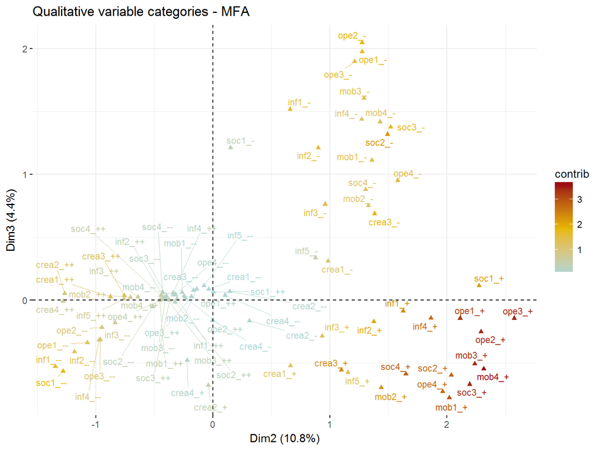

```r
fviz_mfa_var(resMFA, "quali.var", axes=c(2,3), col.var="contrib", gradient.cols=c("#abd7d8","#E7B800","#9b0312"), repel=TRUE, labelsize=3)
```

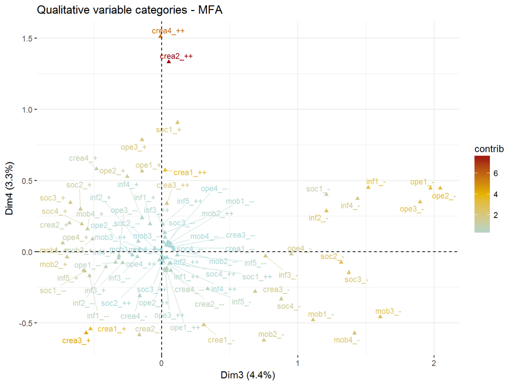

```r
fviz_mfa_var(resMFA, "quali.var", axes=c(3,4), col.var="contrib", gradient.cols=c("#abd7d8","#E7B800","#9b0312"), repel=TRUE, labelsize=3)
```

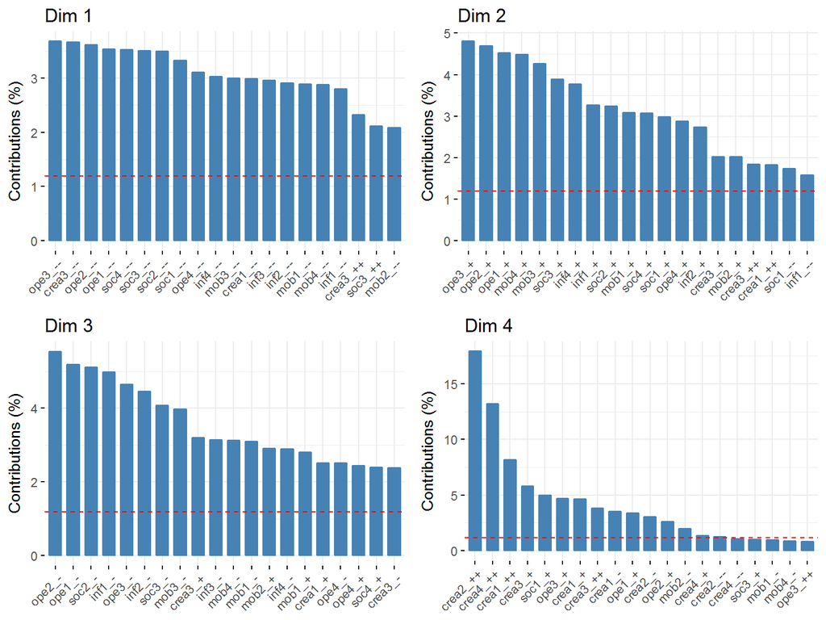

```r
# Contributions des modalités aux 4 premières dimensions
p1=fviz_contrib(resMFA, choice="quali.var", axes=1, top=20, palette="jco") + ggtitle("Dim 1")
p2=fviz_contrib(resMFA, choice="quali.var", axes=2, top=20, palette="jco") + ggtitle("Dim 2")
p3=fviz_contrib(resMFA, choice="quali.var", axes=3, top=20, palette="jco") + ggtitle("Dim 3")
p4=fviz_contrib(resMFA, choice="quali.var", axes=4, top=20, palette="jco") + ggtitle("Dim 4")
grid.arrange(p1,p2,p3,p4, ncol=2, nrow=2)
```

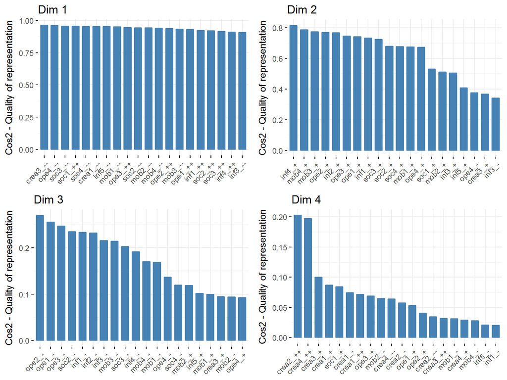

```r
# Cos2 des modalités sur les 4 premières dimensions
p1=fviz_cos2(resMFA, choice="quali.var", axes=1, top=20, palette="jco") + ggtitle("Dim 1")
p2=fviz_cos2(resMFA, choice="quali.var", axes=2, top=20, palette="jco") + ggtitle("Dim 2")
p3=fviz_cos2(resMFA, choice="quali.var", axes=3, top=20, palette="jco") + ggtitle("Dim 3")
p4=fviz_cos2(resMFA, choice="quali.var", axes=4, top=20, palette="jco") + ggtitle("Dim 4")
grid.arrange(p1,p2,p3,p4, ncol=2, nrow=2)
```

Une analyse plus détaillée des contributions des modalités des variables actives de l’AFM à la construction des premiers axes montre que :

- Axe 1
  - contribution positive : les modalités “Cela ne vous ressemble pas du tout” de nombreuses variables parmi lesquelles les 4 compétences opérationnelles, crea3, les 4 sociales, inf4, mob3, crea1, etc.
  - contribution négative : les modalités “Cela vous ressemble beaucoup” des variables crea3, crea1, soc3, etc.
- Axe 2
  - contribution positive : les modalités “Cela vous ressemble plutôt bien” de nombreuses variables parmi lesquelles les 4 compétences opérationnelles, les 4 mobiles, soc3, soc2, inf4, inf1, etc.
  - contribution négative : les modalités “Cela vous ressemble beaucoup” ou “Cela ne vous ressemble pas du tout” des variables crea3, crea1, soc1, inf1, etc.
- Axe 3
  - contribution positive : les modalités “Cela vous ressemble assez peu” de nombreuses variables parmi lesquelles les 4 compétences opérationnelles, soc2, inf1, inf2, soc3, mob3, etc.
  - contribution négative : les modalités “Cela vous ressemble plutôt bien” des variables crea3, mob2, mob1, crea1, ope4, soc4, etc.
- Axe 4
  - contribution positive : les modalités “Cela vous ressemble beaucoup” des variables de compétences créatives.
  - contribution négative : les modalités “Cela vous ressemble plutôt bien” et “Cela vous ressemble assez peu” des variables de compétences créatives.

### Classification ascendante hiérarchique sur le résultat de l’AFM

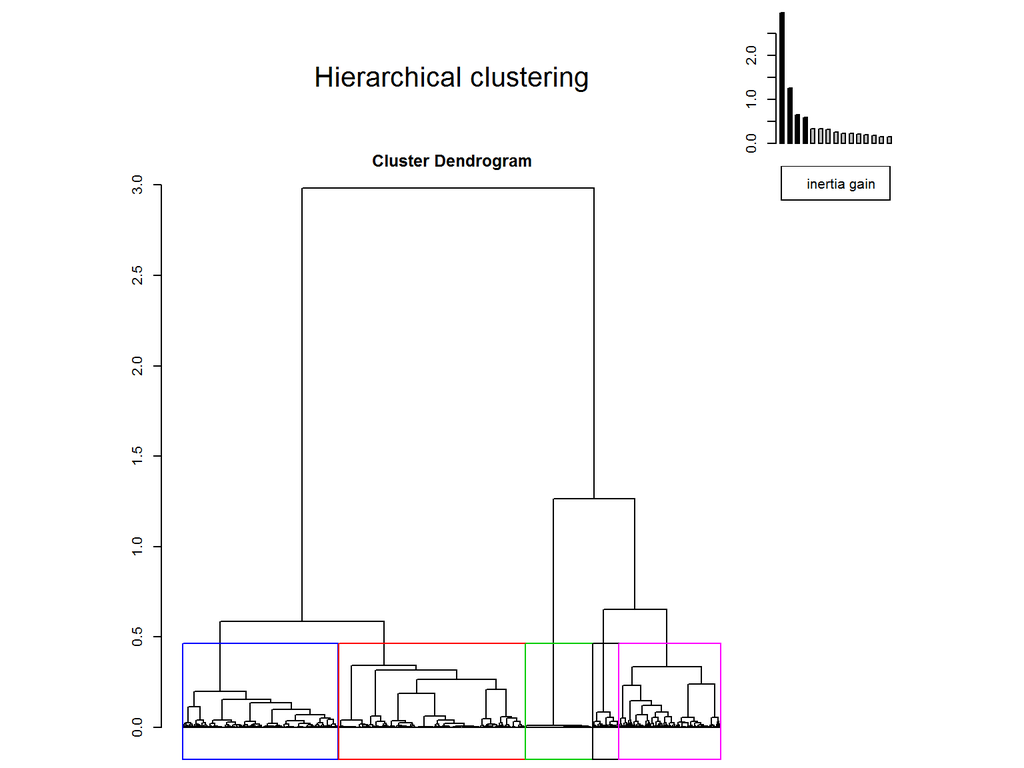

```r
#resHCPC=HCPC(resMFA)
nbClasse=5
# partition en 5 ok un peu global -> sans doute la plus optimale / claire
# 6 ok (distingue les crea++ en cl1, notamment crea4++ coder),
# 7 ok commence à être fin (distingue les - et les -- chez les internautes),
# 8 trop fin (sépare les crea4++ et +), 9 trop fin (même séparation que pour 8 au niveau des crea)
resHCPC=HCPC(resMFA, nb.clust=nbClasse, graph=FALSE)
# resHCPC=HCPC(resMFA,nb.clust=9, graph=FALSE)

# Dendrogramme
plot(resHCPC, choice="tree", labels=FALSE)
```

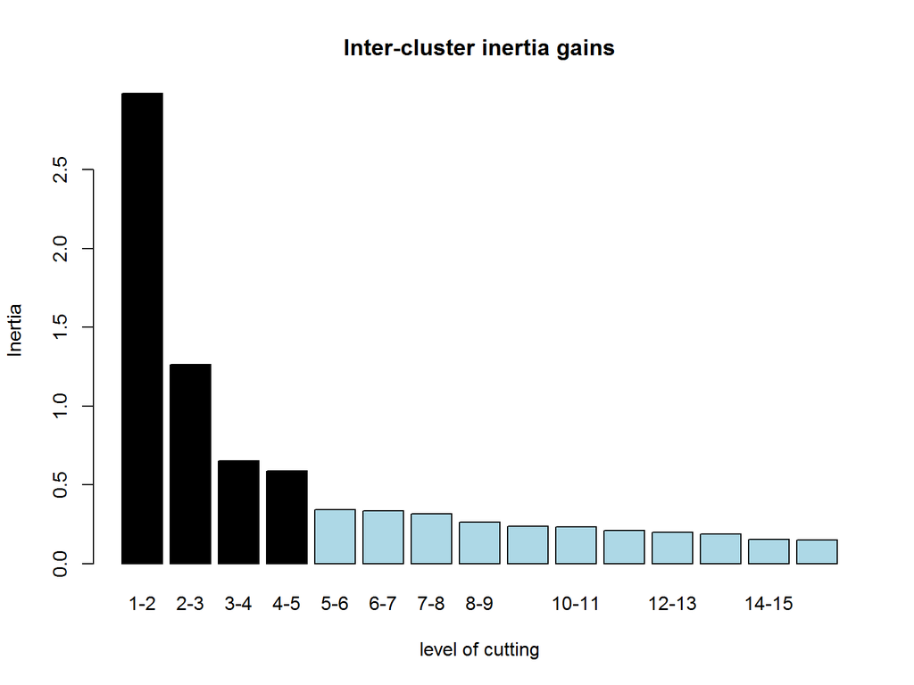

```r
# Nb de classes
plot(resHCPC, choice="bar")
```

```r
skillClust=resHCPC$data.clust
skillClust$poids=as.numeric(as.character(skillClust$poids))
# Répartition par classe
freq(wtd.table(skillClust$clust, weights=skillClust$poids))
```

```
##       n    % val%
## 1 371.3 22.9 22.9
## 2 584.6 36.0 36.0
## 3 161.3  9.9  9.9
## 4 238.9 14.7 14.7
## 5 266.8 16.4 16.4
```

```r
#catdes(skillClust,38)

# # Description des classes
#
# head(round(catdes(skillClust,38,proba=0.01,row.w=skillClust$poids)$category$`1`,2),45)
# head(round(catdes(skillClust,38,proba=0.01,row.w=skillClust$poids)$category$`2`,2),45)
# head(round(catdes(skillClust,38,proba=0.01,row.w=skillClust$poids)$category$`3`,2),45)
# head(round(catdes(skillClust,38,proba=0.01,row.w=skillClust$poids)$category$`4`,2),45)
# head(round(catdes(skillClust,38,proba=0.01,row.w=skillClust$poids)$category$`5`,2),45)
# head(round(catdes(skillClust,38,proba=0.01,row.w=skillClust$poids)$category$`6`,2),45)
# head(round(catdes(skillClust,38,proba=0.01,row.w=skillClust$poids)$category$`7`,2),45)
# head(round(catdes(skillClust,38,proba=0.01,row.w=skillClust$poids)$category$`8`,2),45)
# head(round(catdes(skillClust,38,proba=0.01,row.w=skillClust$poids)$category$`9`,2),45)
```

Le dendrogramme laisse deviner 5 classes naturelles. Ce choix est confirmé par le saut d’inertie présent entre le passage de 4 à 5 classes et le passage de 5 à 6 classes.

Les classes obtenues présentent des effectifs allant de 161 répondants (soit 10%) pour la plus petite à 585 répondants (soit 36%) pour la plus grande.

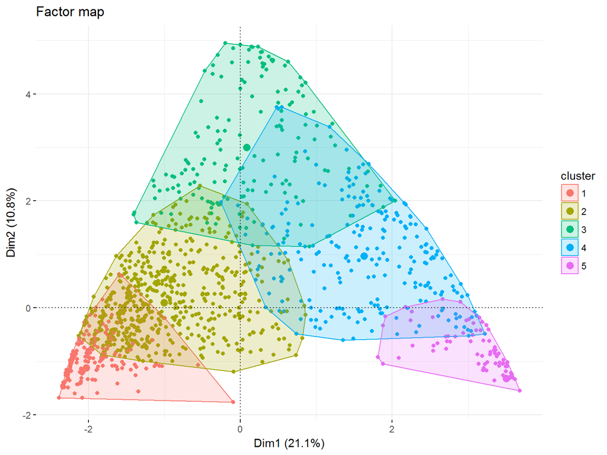

```r
# Représentation des classes sur les premiers plans factoriels

# plot(resHCPC, choice="map", ind.names=FALSE, draw.tree=FALSE, axes=c(1,2))
# plot(resHCPC, choice="map", ind.names=FALSE, draw.tree=FALSE, axes=c(2,3))
# plot(resHCPC, choice="map", ind.names=FALSE, draw.tree=FALSE, axes=c(3,4))
# plot(resHCPC, choice="map", ind.names=FALSE, draw.tree=FALSE, axes=c(4,5))

fviz_cluster(resHCPC, repel=FALSE, shape=16, ellipse=TRUE, geom="point",
             ggtheme=theme_minimal(), main="Factor map") +
  geom_vline(xintercept=0, linetype="dotted") + geom_hline(yintercept=0, linetype="dotted")
```

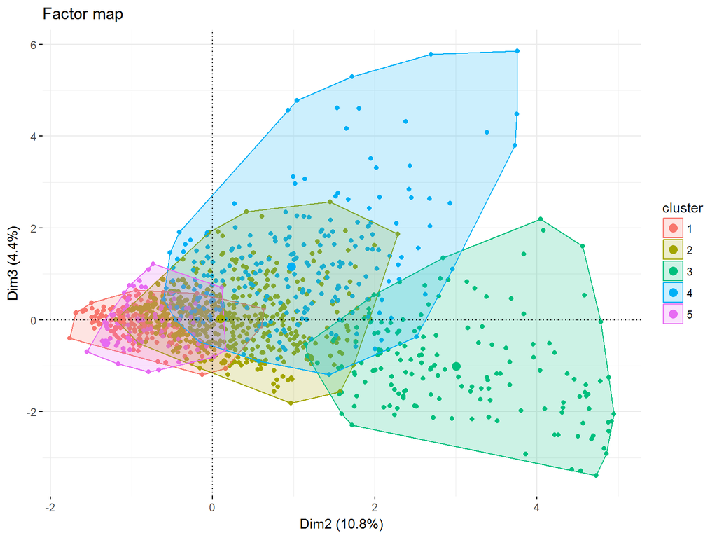

```r
fviz_cluster(resHCPC, repel=FALSE, shape=16, ellipse=TRUE, geom="point",
             ggtheme=theme_minimal(), main="Factor map", axes=c(2,3)) +
  geom_vline(xintercept=0, linetype="dotted") + geom_hline(yintercept=0, linetype="dotted")
```

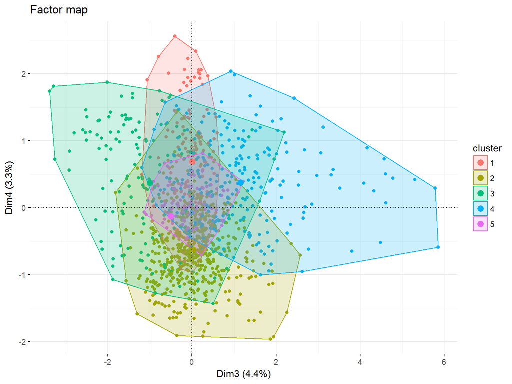

```r
fviz_cluster(resHCPC, repel=FALSE, shape=16, ellipse=TRUE, geom="point",
             ggtheme=theme_minimal(), main="Factor map", axes=c(3,4)) +
  geom_vline(xintercept=0, linetype="dotted") + geom_hline(yintercept=0, linetype="dotted")
```

```r
# library(tibble)
# a1=rownames_to_column(skillClust)
# a2=rownames_to_column(data[,c("WIP.outil_4","WIP.outil_5")])
# a=left_join(a1,a2,by="rowname")
# round(prop.table(table(a$clust,a$WIP.outil_5),1)*100)
```

La projection des classes sur le plan 1-2 laisse apparaître des classes plutôt bien séparées, laissant augurer des profils de compétences distincts.

## Description des classes (signif à 1%)

### Classe 1

```
##                          Cla/Mod Mod/Cla Global p.value v.test
## crea1=crea1_++             75.27   86.76  26.37    0.00  29.22
## crea3=crea3_++             61.46   95.23  35.45    0.00  28.32
## mob1=mob1_++               46.91   96.64  47.13    0.00  23.62
## inf5=inf5_++               60.55   79.97  30.22    0.00  23.22
## mob2=mob2_++               56.04   84.21  34.38    0.00  22.97
## mob4=mob4_++               44.70   96.69  49.49    0.00  22.64
## crea2=crea2_++             95.87   44.64  10.65    0.00  22.39
## ope4=ope4_++               43.71   96.29  50.40    0.00  22.09
## mob3=mob3_++               42.62   97.41  52.29    0.00  22.03
## soc3=soc3_++               41.10   97.60  54.33    0.00  21.23
## soc2=soc2_++               40.25   98.34  55.90    0.00  21.21
## inf1=inf1_++               38.41   98.41  58.62    0.00  20.17
## soc4=soc4_++               42.70   92.29  49.45    0.00  20.10
## inf3=inf3_++               51.80   79.01  34.90    0.00  20.07
## inf2=inf2_++               41.78   92.49  50.65    0.00  19.58
## inf4=inf4_++               38.12   97.17  58.32    0.00  19.50
## ope2=ope2_++               35.72   99.43  63.69    0.00  19.15
## ope1=ope1_++               35.79   99.18  63.41    0.00  19.02
## ope3=ope3_++               34.22   99.45  66.50    0.00  18.12
## aise=aise_++               52.62   67.74  29.46    0.00  17.85
## crea4=crea4_++             95.17   25.36   6.10    0.00  16.05
## soc1=soc1_++               30.33   99.69  75.19    0.00  15.16
## internaute=oui             26.55   99.69  85.92    0.00  10.75
## age=18-24                  52.27   26.26  11.50    0.00   9.26
## ecrit=ecrit_PFPJ           48.30   29.25  13.85    0.00   9.17
## csp=csp_Etudiant           58.21   19.04   7.48    0.00   8.85
## prof=prof_Etudiant         58.21   19.04   7.48    0.00   8.85
## crea4=crea4_+              66.00   12.34   4.28    0.00   7.91
## debInt=>=17an              37.05   34.30  21.18    0.00   6.72
## crea2=crea2_+              52.07   13.41   5.89    0.00   6.42
## etude=etude_SupLong        35.52   34.81  22.42    0.00   6.26
## sexe=Homme                 29.37   63.93  49.80    0.00   6.20
## statFam=célib              34.73   35.69  23.52    0.00   6.15
## csp=csp_CSP+               32.18   40.95  29.12    0.00   5.58
## crea4=crea4_-              46.37   13.17   6.50    0.00   5.55
## age=25-34                  35.63   25.57  16.42    0.00   5.23
## prof=prof_Cadre            39.59   17.45  10.08    0.00   5.09
## etude=etude_SupCourt       33.51   26.69  18.22    0.00   4.63
## crea2=crea2_-              38.54   15.91   9.45    0.00   4.60
## agglo=8                    32.51   24.52  17.26    0.00   4.09
## nbFoy=3-4p                 28.88   41.11  32.57    0.00   3.99
## ecrit=ecrit_jour           32.80   21.51  15.01    0.00   3.87
## vie=vie_très confortable   47.87    5.90   2.82    0.00   3.75
## revenu=revenu_DK           49.01    5.79   2.70    0.00   3.65
## actu=actu_PFPJ             26.11   57.41  50.31    0.00   3.10
## ecrit=ecrit_sem            30.30   22.17  16.74    0.00   3.06
## nbFoy=5p+                  32.88   11.98   8.34    0.01   2.71
```

La classe 1 est la deuxième classe la plus importante en taille et contient environ 23% des répondants.  
Elle regroupe les individus se déclarant très à l’aise avec l’ensemble des compétences abordées, quel que soit le type de compétences, même créatives. En effet, 87% d’entre eux déclarent savoir comment créer quelque chose de nouveau à partir d’images, de musiques ou de vidéos, et 95% savoir mettre en ligne du contenu. Cette classe rassemble 96% des répondants ayant déclaré savoir créer un site web et 95% de ceux déclarant savoir coder/programmer dans un langage informatique. Ces personnes sont internautes (100%). Parmi elles, les jeunes (18-24 ans 26%, 25-34 ans 26%) sont sur-représentés, tout comme les étudiants et les cadres, les hommes, les personnes ayant fait des études supérieures courtes et longues, les célibataires, les CSP+, les personnes déclarant avoir une vie très confortable, vivant à 3 ou 4 personnes par foyer, ecrit et actu fréquent.

### Classe 2

```
##                         Cla/Mod Mod/Cla Global p.value v.test
## ope3=ope3_++              52.24   96.43  66.50    0.00  21.17
## ope2=ope2_++              52.97   93.66  63.69    0.00  20.35
## ope1=ope1_++              52.79   92.92  63.41    0.00  19.83
## soc1=soc1_++              47.36   98.85  75.19    0.00  18.99
## inf4=inf4_++              53.04   85.87  58.32    0.00  17.58
## inf1=inf1_++              51.69   84.12  58.62    0.00  16.23
## soc3=soc3_++              52.98   79.90  54.33    0.00  15.86
## soc2=soc2_++              50.93   79.02  55.90    0.00  14.40
## internaute=oui            41.78   99.66  85.92    0.00  14.16
## soc4=soc4_++              51.67   70.92  49.45    0.00  13.15
## crea3=crea3_+             69.21   35.92  18.69    0.00  13.12
## ope4=ope4_++              51.10   71.49  50.40    0.00  12.87
## mob3=mob3_++              50.13   72.77  52.29    0.00  12.47
## inf2=inf2_++              49.81   70.03  50.65    0.00  11.76
## mob4=mob4_++              49.85   68.48  49.49    0.00  11.52
## crea1=crea1_+             66.53   30.53  16.53    0.00  11.09
## mob1=mob1_++              48.05   62.87  47.13    0.00   9.58
## aise=aise_+               48.34   60.17  44.84    0.00   9.31
## crea1=crea1_-             62.32   24.17  13.97    0.00   8.61
## inf3=inf3_+               49.26   38.89  28.44    0.00   6.85
## debInt=]12,16]an          50.01   29.26  21.08    0.00   5.96
## crea2=crea2_--            39.84   81.85  74.01    0.00   5.53
## crea4=crea4_--            38.88   89.72  83.13    0.00   5.35
## age=25-34                 48.71   22.20  16.42    0.00   4.69
## inf5=inf5_-               52.60   14.99  10.27    0.00   4.63
## mob2=mob2_-               55.21   11.12   7.26    0.00   4.36
## inf3=inf3_++              43.16   41.81  34.90    0.00   4.31
## inf5=inf5_+               48.30   20.33  15.16    0.00   4.30
## ecrit=ecrit_jour          48.38   20.15  15.01    0.00   4.27
## nbFoy=3-4p                43.06   38.93  32.57    0.00   4.09
## prof=prof_Profint         47.35   20.15  15.33    0.00   3.99
## age=35-49                 43.36   32.47  26.98    0.00   3.71
## csp=csp_CSP+              42.96   34.73  29.12    0.00   3.67
## mob2=mob2_++              42.14   40.22  34.38    0.00   3.67
## etude=etude_SupLong       44.20   27.51  22.42    0.00   3.65
## debInt=>=17an             44.65   26.26  21.18    0.00   3.63
## agglo=67                  42.81   34.69  29.19    0.00   3.63
## aise=aise_++              42.23   34.53  29.46    0.00   3.35
## csp=csp_CSP-              40.78   46.66  41.22    0.00   3.34
## prof=prof_Employé         44.96   20.86  16.71    0.00   3.33
## crea3=crea3_-             48.60   12.29   9.11    0.00   3.29
## debInt=]9,12]an           42.64   28.04  23.68    0.00   3.09
## etude=etude_SupCourt      43.39   21.95  18.22    0.00   2.82
## statFam=concub            44.29   17.15  13.95    0.01   2.73
## statFam=pacsé             49.63    6.79   4.93    0.01   2.61
## revenu=revenu_2900-4000   43.13   20.03  16.73    0.01   2.60
```

La classe 2 est la classe la plus grande avec 36% des répondants. La classe 2 regroupe les individus déclarant également de très bonnes compétences opérationnelles, informationnelles, sociales et mobiles, mais contrairement aux individus de la classe 1 ils sont nettement moins à l’aise avec les compétences créatives et notamment pour ce qui a trait à la création de site et à la programmation. En effet, 82% (resp. 90%) d’entre eux disent que savoir créer un site web (resp. programmer) ne leur ressemble pas du tout. Prof intermédiare, supérieur court et long, 25-34, 35-49 ans, 3-4 personnes dans le foyer, ancien sur internet, CSP+ et -, employés, revenu 2900-4000€, ancienneté >=17 ans et 12-16 ans, très à l’aise avec Internet, internaute (100%)

### Classe 3

```
##                   Cla/Mod Mod/Cla Global p.value v.test
## mob4=mob4_+         56.45   70.22  12.36    0.00  18.77
## mob3=mob3_+         54.02   68.33  12.57    0.00  18.08
## soc3=soc3_+         56.54   63.65  11.19    0.00  17.68
## ope2=ope2_+         50.20   66.41  13.15    0.00  17.16
## mob1=mob1_+         52.66   59.31  11.19    0.00  16.32
## inf4=inf4_+         39.41   72.32  18.23    0.00  16.27
## ope1=ope1_+         44.02   66.06  14.91    0.00  16.12
## soc4=soc4_+         42.50   67.02  15.67    0.00  15.91
## ope3=ope3_+         52.36   56.24  10.67    0.00  15.75
## soc2=soc2_+         50.33   54.76  10.81    0.00  15.08
## ope4=ope4_+         48.18   53.47  11.03    0.00  14.52
## inf2=inf2_+         29.94   73.19  24.29    0.00  13.95
## inf1=inf1_+         32.51   67.99  20.78    0.00  13.92
## mob2=mob2_+         38.70   56.05  14.39    0.00  13.27
## inf3=inf3_+         23.47   67.17  28.44    0.00  10.75
## soc1=soc1_+         42.74   34.31   7.98    0.00  10.37
## inf5=inf5_+         30.53   46.58  15.16    0.00  10.15
## aise=aise_+         17.81   80.38  44.84    0.00   9.81
## crea3=crea3_+       23.60   44.41  18.69    0.00   8.06
## crea3=crea3_-       26.99   24.73   9.11    0.00   6.30
## internaute=oui      11.42   98.72  85.92    0.00   5.94
## crea1=crea1_+       20.21   33.62  16.53    0.00   5.61
## crea1=crea1_-       21.25   29.87  13.97    0.00   5.52
## debInt=]9,12]an     15.64   37.27  23.68    0.00   4.08
## mob2=mob2_-         21.10   15.40   7.26    0.00   3.80
## soc4=soc4_-         21.20   13.78   6.46    0.00   3.50
## ope4=ope4_-         20.25   13.52   6.63    0.00   3.38
## inf5=inf5_-         17.69   18.27  10.27    0.00   3.15
## etude=etude_REF     71.99    1.74   0.24    0.00   2.91
## age=35-49           13.42   36.44  26.98    0.00   2.83
## soc2=soc2_-         18.93   12.63   6.63    0.00   2.83
## prof=prof_Employé   14.60   24.56  16.71    0.01   2.79
```

La classe 3 est la plus petite avec environ 10% des répondants. C’est la classe des individus ayant de plutôt bonnes compétences dans tous les types abordés, même s’ils sont globalement moins à l’aise avec les compétences créatives. 35-49 ans, employé, à l’aise avec Internet, ancienneté 9-12 ans, internautes (99%)

### Classe 4

```
##                     Cla/Mod Mod/Cla Global p.value v.test
## inf2=inf2_-           65.18   36.75   8.30    0.00  14.28
## aise=aise_-           58.59   40.68  10.22    0.00  14.12
## crea1=crea1_--        28.79   84.32  43.12    0.00  14.11
## mob2=mob2_--          28.29   84.51  43.97    0.00  13.98
## crea3=crea3_--        31.09   77.60  36.75    0.00  13.93
## mob1=mob1_--          30.94   74.92  35.65    0.00  13.43
## inf1=inf1_-           69.43   27.92   5.92    0.00  12.76
## soc3=soc3_--          31.99   64.41  29.64    0.00  12.15
## inf5=inf5_--          26.60   80.13  44.36    0.00  12.15
## inf1=inf1_+           36.96   52.17  20.78    0.00  11.90
## mob4=mob4_--          29.60   69.21  34.42    0.00  11.85
## mob3=mob3_--          29.92   63.88  31.43    0.00  11.29
## soc4=soc4_--          31.32   60.47  28.42    0.00  11.21
## ope4=ope4_--          29.52   64.03  31.93    0.00  11.09
## crea2=crea2_--        19.55   98.27  74.01    0.00  11.03
## inf3=inf3_-           40.96   41.11  14.78    0.00  10.98
## ope2=ope2_-           80.46   17.32   3.17    0.00  10.68
## ope1=ope1_-           79.98   17.30   3.18    0.00  10.55
## ope3=ope3_-           77.64   16.29   3.09    0.00  10.20
## ope1=ope1_+           38.41   38.91  14.91    0.00  10.08
## inf4=inf4_+           33.82   41.89  18.23    0.00   9.35
## inf4=inf4_-           65.18   16.95   3.83    0.00   9.15
## soc2=soc2_-           50.30   22.66   6.63    0.00   9.05
## soc2=soc2_--          28.59   51.77  26.66    0.00   9.04
## ope3=ope3_+           39.85   28.89  10.67    0.00   8.69
## soc1=soc1_+           43.46   23.55   7.98    0.00   8.28
## crea4=crea4_--        17.42   98.34  83.13    0.00   8.08
## ope4=ope4_-           42.95   19.35   6.63    0.00   7.30
## ope2=ope2_+           32.09   28.65  13.15    0.00   6.91
## soc3=soc3_-           45.32   14.92   4.85    0.00   6.75
## mob3=mob3_-           48.50   12.21   3.71    0.00   6.29
## inf2=inf2_+           24.81   40.93  24.29    0.00   6.22
## soc1=soc1_-           59.81    8.70   2.14    0.00   6.20
## age=>=65              23.95   34.63  21.29    0.00   5.24
## mob1=mob1_-           33.43   13.69   6.03    0.00   4.86
## mob4=mob4_-           38.30    9.70   3.73    0.00   4.50
## age=50-64             22.04   35.66  23.82    0.00   4.43
## csp=csp_Retraité      22.31   33.60  22.17    0.00   4.37
## prof=prof_Retraité    22.31   33.60  22.17    0.00   4.37
## debInt=<=9an          19.92   46.07  34.05    0.00   4.14
## ecrit=ecrit_jam       20.13   43.17  31.58    0.00   4.07
## internaute=oui        16.09   93.93  85.92    0.00   4.05
## etude=etude_CAP-BEP   20.74   35.49  25.19    0.00   3.87
## ope2=ope2_--          21.25   28.86  19.99    0.00   3.59
## soc4=soc4_-           27.87   12.23   6.46    0.00   3.54
## statFam=marié         18.53   48.08  38.20    0.00   3.38
## ecrit=ecrit_MS        22.43   18.04  11.84    0.00   3.04
## sexe=Femme            17.30   59.00  50.20    0.00   2.94
## inf3=inf3_--          19.21   28.56  21.89    0.01   2.60
```

La classe 4 contient environ 15% de la population. C’est la classe des individus ayant des compétences faibles ou très faibles dans la plupart des compétences abordées. Ils se sentent néanmoins assez à l’aise sur quelques points comme la recherche d’informations en ligne, l’utilisation de bons mots-clés, rechercher des itinéraires en ligne, ouvrir un fichier téléchargé, envoyer un email et y joindre un document, se connecter à un réseau wifi. Bref, quelques usages assez basiques. 94% de ces individus sont internautes. 50-64 ans et >=65 ans, retraités, assez peu à l’aise avec Internet, CAP-BEP, mariés, femme, ancienneté < 9 ans

### Classe 5

```
##                        Cla/Mod Mod/Cla Global p.value v.test
## ope3=ope3_--             80.72   96.91  19.73       0  32.20
## ope1=ope1_--             83.88   94.39  18.50       0  31.92
## inf2=inf2_--             88.92   90.65  16.76       0  31.76
## inf1=inf1_--             95.57   85.33  14.68       0  31.75
## inf4=inf4_--             79.07   94.36  19.62       0  30.96
## soc1=soc1_--             92.66   82.82  14.69       0  30.34
## inf3=inf3_--             72.48   96.52  21.89       0  30.20
## ope2=ope2_--             76.07   92.52  19.99       0  29.76
## aise=aise_nonInt         91.37   78.25  14.08       0  28.88
## internaute=non           91.37   78.25  14.08       0  28.88
## soc2=soc2_--             58.96   95.62  26.66       0  26.96
## soc4=soc4_--             56.02   96.86  28.42       0  26.64
## ope4=ope4_--             51.07   99.22  31.93       0  26.44
## soc3=soc3_--             53.90   97.18  29.64       0  26.23
## mob4=mob4_--             46.85   98.12  34.42       0  24.72
## mob3=mob3_--             49.87   95.37  31.43       0  24.49
## crea3=crea3_--           44.44   99.33  36.75       0  24.47
## mob1=mob1_--             45.06   97.72  35.65       0  24.01
## debInt=<=9an             44.68   92.56  34.05       0  22.13
## crea1=crea1_--           37.83   99.25  43.12       0  22.13
## inf5=inf5_--             36.63   98.84  44.36       0  21.47
## mob2=mob2_--             36.54   97.74  43.97       0  20.93
## etude=etude_Collège      57.37   46.90  13.44       0  15.25
## age=>=65                 45.64   59.11  21.29       0  15.15
## csp=csp_Retraité         43.49   58.66  22.17       0  14.35
## prof=prof_Retraité       43.49   58.66  22.17       0  14.35
## ecrit=ecrit_jam          36.45   70.02  31.58       0  14.26
## crea2=crea2_--           22.21  100.00  74.01       0  13.15
## crea4=crea4_--           19.69   99.58  83.13       0   9.77
## statFam=veuf             55.27   20.59   6.12       0   9.23
## nbFoy=1p                 28.16   44.97  26.25       0   7.26
## revenu=revenu_< 1400     26.63   40.80  25.18       0   6.17
## vie=vie_très difficile   29.30   14.31   8.03       0   3.81
## aise=aise_--             48.23    4.12   1.40       0   3.49
## soc1=soc1_-              40.19    5.24   2.14       0   3.34
## nbFoy=2p                 20.80   41.47  32.78       0   3.30
## prof=prof_Agri           52.37    2.59   0.81       0   3.03
## etude=etude_CAP-BEP      21.38   32.76  25.19       0   2.97
## revenu=revenu_REF        26.82   12.54   7.69       0   2.94
## actu=actu_jam            43.40    3.43   1.30       0   2.84
## vie=vie_difficile        22.79   22.29  16.07       0   2.83
## age=50-64                21.16   30.66  23.82       0   2.82
```

La classe 5 contient environ 16% des répondants. Ces individus ont des compétences très faibles sur l’ensemble des types de compétences (plus encore que la classe 4). 78% ne sont pas internautes (grosse différence par rapport à la classe 4). >=65 ans, 50-64 ans, retraités, veuf, 1p dans le foyer, revenu < 1400€, vie très difficile, ancienneté < 9 ans, pas du tout à l’aise avec Internet, agriculteurs, CAP-BEP